# Calibrated Selex Curve

Ernesto

November 28, 2017

This is a relatively simple demo. I wanted to make sure the boxcar method integrates well within the rest of POSEIDON.

Here’s a simple simulation problem. There is a very basic 1-cell world, 20 boats, fishing one species. The species is modelled with the fixed boxcar method and uses Von Bertlanffy parameters for the *Aphareus rutilians* (chosen exclusively because it comes first alphabetically).

| Measure | Value |
| --- | --- |
| Min Length | 10cm |
| Max Length | 113cm |
| Number of bins | 100 |
| Yearly K | 0.364 |
| Allometric $\alpha$ | 0.015 |
| Allometric $\beta$ | 2.961 |
| Yearly Mortality Rate | 0.1 |

The model is basically non-spatial:

[video not shown]

The environmental dynamics is also very simple. The world starts with 10M recruits (that is fish at bin-length 0). Every year 100,000 new recruits join the fishery (regardless of how many fish are left or if there is any spawner). The recruitment is continuous (every day some fish is recruited).

We have the empirical catch-length frequency for Aphaerus rutilans from Peter’s data-set:

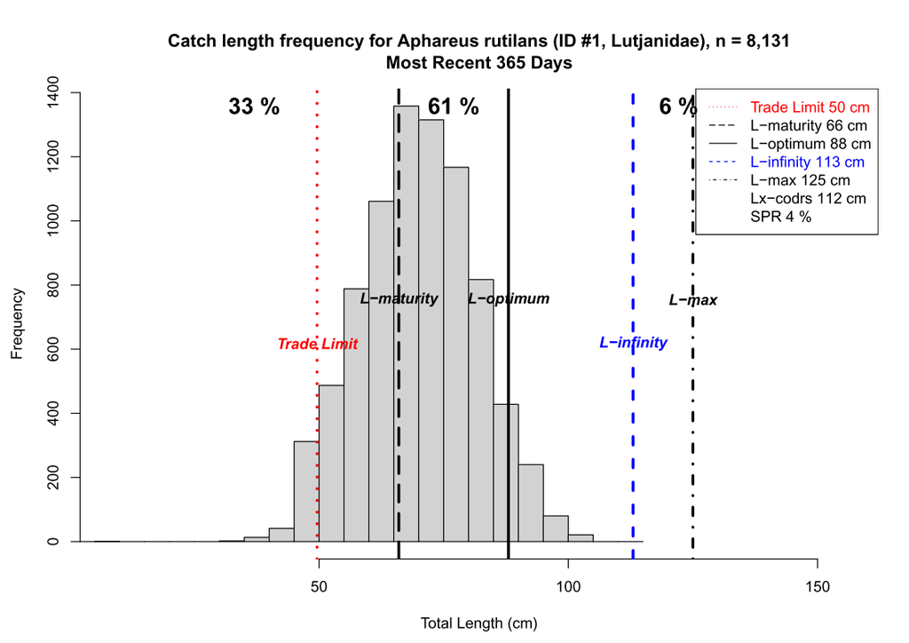

The question is, we want our dumb non-spatial model to generate the same length-frequency catch data as what was observed empirically. We let the model run for 10 years and compare what we caught in the simulation with Peter’s data.

Fishers go out 365 days a year (stopping 12 hours between trips) and each hour catch fish in each bin depending on a logistic selectivity curve:
$$\displaystyle \text{Selectivity}(l)= \frac{q}{1+e^{-\log_{10}(19)\frac{(l-a)}{b}}}$$
We want to tune the three parameters in order for our model to generate the catch-length frequency most similar to reality.

| Parameter | Meaning |
| --- | --- |
| q | Catchability |
| $a$ | Selectivity intercept |
| $b$ | Selectivity slope |

That’s a straightforward 3 dimensional optimization (minimize histogram distance) and we can use the usual Bayesian mechanism to get to result:

| Parameter | Meaning | Value |
| --- | --- | --- |
| q | Catchability | 0.000029 |
| $a$ | Selectivity intercept | 67.486064 |
| $b$ | Selectivity slope | 7.258574 |

And the histograms look really close

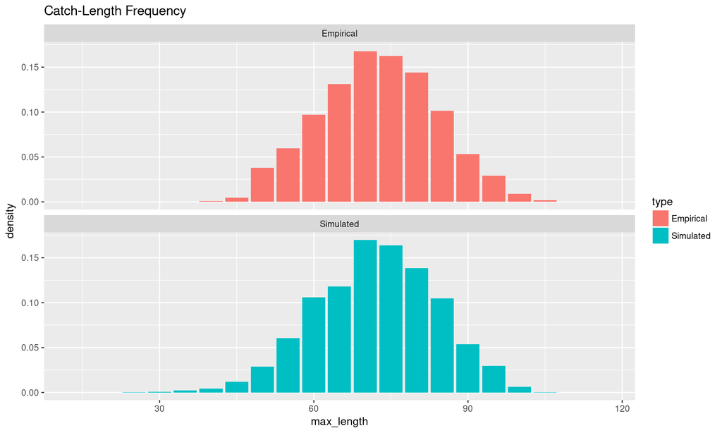

In short, we can integrate the new framework with all the other features of POSEIDON no problem.

What needs to happen next is to implement the fractional boxcar proper and start doing some serious speed comparisons.

| Parameter | Meaning | Value |
| --- | --- | --- |
| q | Catchability | 0.000029 |
| $a$ | Selectivity intercept | 67.486064 |
| $b$ | Selectivity slope | 7.258574 |

## Lutjanus Erythropterus

Same work, but this time with a species which tends to get caught later on in life.

| Measure | Value |
| --- | --- |
| Min Length | 20cm |
| $L_{\infty}$ | 63cm |
| Number of bins | 100 |
| Yearly K | 0.3491 |
| Allometric $\alpha$ | 0.024 |
| Allometric $\beta$ | 2.870 |
| Yearly Mortality Rate | 0.1 |

Where $K$ comes from fishbase average.

Same selectivity curve, same optimization and I get:

| Parameter | Meaning | Value |
| --- | --- | --- |
| q | Catchability | 0.000005152 |
| $a$ | Selectivity intercept | 51.00229164 |
| $b$ | Selectivity slope | 7.15662491 |

And the following histogram:

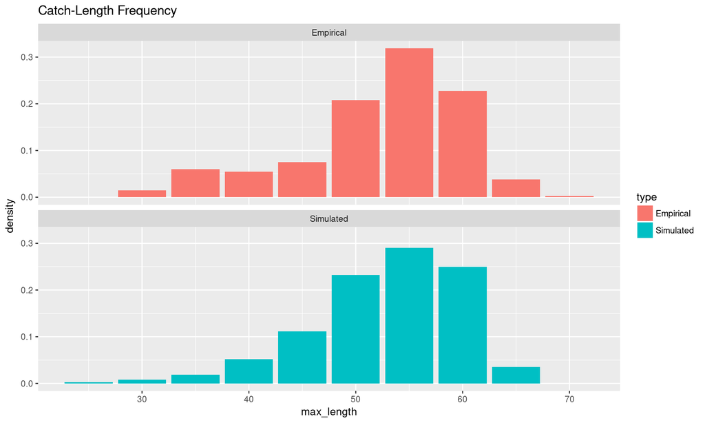

Simulated a bit smoother than empirical and of course we lose out observations above $L_{\infty}$